# Child Mortality and Fertility: Two Sides of the Demographic Transition

Alexander Temerev

10 June 2026

## Introduction

This report explores the relationship between two country-level indicators from [Gapminder](https://gapminder.org/data) for the year **2020**:

- **Child mortality** — deaths of children under five years of age, per 1,000 live births;
- **Total fertility rate** — average number of children born per woman.

These two indicators are the core of the *demographic transition*: as fewer children die, families have fewer children. The analysis below maps both indicators across the world and examines how tightly they are related.

## Map 1: Child mortality (2020)

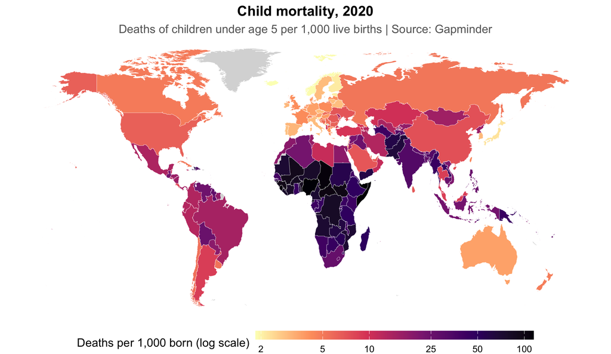

## Map 2: Total fertility rate (2020)

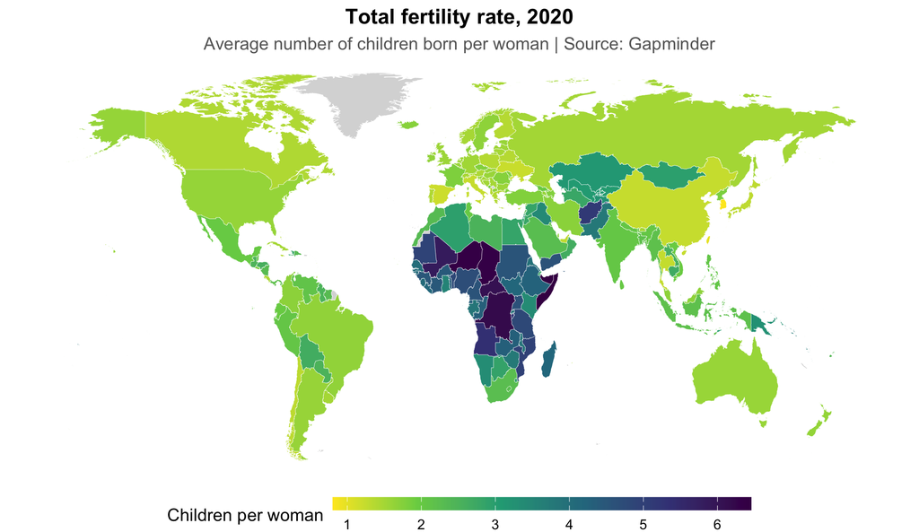

The fertility map is strikingly similar to the mortality map: the same Sahel and Central African belt where child mortality is highest is also where women have the most children (5–7 per woman in Niger, Chad, Somalia, and the DR Congo), while most of Europe and East Asia are below the replacement level of about 2.1 children per woman.

## Relationship between the two indicators

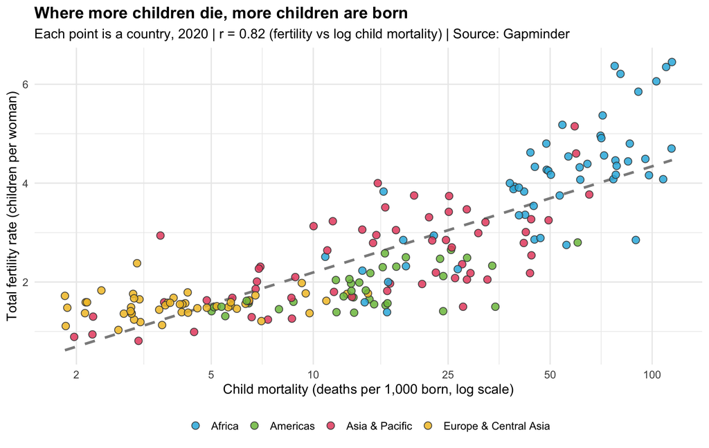

### Description and interpretation

This is the classic signature of the **demographic transition**. Several mechanisms link the two indicators:

- **Replacement and insurance effects.** Where child death is common, families have more children to compensate for expected losses and as insurance for old age.
- **Shared underlying drivers.** Poverty, limited access to healthcare and contraception, and lower female education raise both child mortality and fertility at the same time, so part of the correlation reflects common causes rather than a direct effect of one indicator on the other.
- **Transition dynamics.** Historically, mortality falls first and fertility follows with a delay of a generation or two. The countries in the upper-right of the plot (mostly in the Sahel) are at an earlier stage of this transition, not on a different path — Gapminder’s time series show them moving along the same curve that Europe and East Asia traversed in the 20th century.

It is worth stressing that **correlation is not causation** here: reducing child mortality does not mechanically reduce fertility, but no country has achieved low fertility while child mortality remained high, which is why child survival is widely seen as a precondition for the fertility transition.

## Personal reflection on the AI workflow

I completed this workshop using an AI coding agent (Claude Code) in the R track. A few observations about the process:

- **What worked well.** The agent handled the entire pipeline — installing R and pandoc, locating the Gapminder indicator files, downloading the CSVs, and writing the R Markdown document — with very little intervention from me. Letting the AI choose the indicator pair produced a more interesting analysis (mortality vs fertility) than the default GDP-vs-life-expectancy example.
- **Where human oversight mattered.** Country names differ between Gapminder and the R `maps` package (“United States” vs “USA”, “Congo, Dem. Rep.” vs “Democratic Republic of the Congo”), and an unsupervised join would have silently dropped a dozen countries from the maps. Checking the unmatched-country list and adding an explicit recode table was the kind of data-quality step that is easy to miss if you accept AI output without verifying it.
- **Takeaway.** The AI was strongest as an *executor* — fast, fluent in ggplot2 idioms, good at boilerplate — while the judgment calls (which indicators, log scale on mortality, the caveat about confounding) are where the human in the loop adds value. Iterating with the AI felt less like delegating and more like pair-working with a very fast junior analyst.

*Data: [Gapminder](https://gapminder.org/data) (free data from World Bank, UN Population Division, and Gapminder estimates, CC-BY). Analysis: R 4.6.0, ggplot2, knitted with R Markdown.*